# 2IS50 – Software Developement for Engineers – 2022-2023

## Intro Lecture

Lecturer: Tom Verhoeff

- Updates for the Intro Lecture 0 recorded previously

Target audience: Students *outside* Computer Science

- Others: check whether 2IS50 is permitted in your study program
- In particular, Mathematics, Data Science

## Why Python?

[figure not shown]

[figure not shown]

Image credit: https://xkcd.com/353/

[TIOBE Index](https://www.tiobe.com/tiobe-index/) for Programming Languages - April 2023

[figure not shown]

Python was TIOBE's programming language of the year 2018.

### Other tools

(Assistance with installation: Thu 04 May, hours 3+4)

- **Git** for *version control*
- **PyCharm** as IDE for standalone Python code
- **Qt5** for *graphical user interfaces*
- **PyTest** for *automated systematic testing*
- **Sphinx** for *documentation*
- **GitLab** for *issue tracking*

## Course Information

- Main entry point: **Canvas.tue.nl**
  - Including Exercise and Assignment deadlines
- Files: **GitLab.tue.nl**
- Online support: **Teams**
  - Channels for asking questions

## Course Structure

- **Lectures** (also recorded beforehand):
  - Tue, hours 5+6, and Thu, hours 1+2
  - Before/after each lecture: Read in **Think Python** (book)
  - Topics alternate: Python – Software Engineering
- Guided **lab sessions**
  - Tue, hours 7+8, and Thu, hours 3+4
  - Online support through **Teams** channels
- **Exercises** (individual): 6x, best 5 count (5%); see schedule
  - Autograded by Momotor (need to score at least 80%)
- **Homework Assignments** (in pairs, except HA-0; 5%+10%+30%); (see schedule)
- **Final Test** (50%; grade at least 5.0)

## Course Schedule

N.B. Irregular weeks in Q4.

5 EC Course = 140 hours = 7 * 20 hours

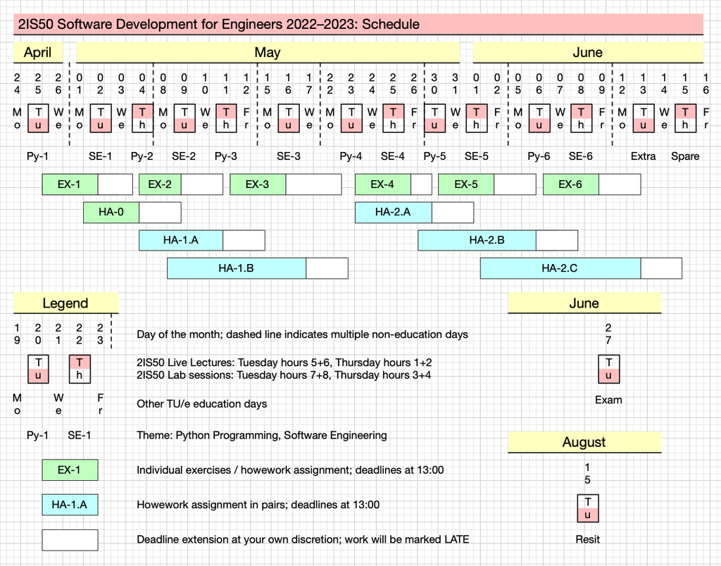

## Instructors and Teaching Assistants

**Instructors**: Kees Huizing, Mazyar Seraj

**Exercises Manager**: Lina Ochoa

**Homework Assignments Manager**: Lars van den Haak

**Teaching Assistants**: Daan, Isidora, Statius, Yang

- First **guided lab session 1.a**: Tue 25 Apr, 15:30–17:15
- Online support via Teams channels

## Points of Action

- Complete the **Intro Survey**
- Find a partner for **Pair Programming**
  - sign up: Canvas > People > Assignment Pairs
- Work on **Exercises 1**

## (End of Notebook)

© 2019-2023 - **TU/e** - Eindhoven University of Technology - Tom Verhoeff